# Evictions v. Homelessness Analysis

## State-fixed effects

[figure not shown]

```r
par(mfrow = c(1,2))
plot(ln_model, which = 1:2)
mtext('ln(homelesscap) = A + B(ln(filerate)) + controls + u', side = 3, line = -2, outer = TRUE)
```

The relationship between filing rate and homelessness seems to vary wildly based on state characteristics. For this reason, a fixed effects model could work better for our data.

$~$

#### Least squares dummy variable model

$$\hat{homelesscap}_{it} = \hat\beta_0(?)
+ \hat\beta_1{filerate}_{it} + \hat\gamma_{AK}{DAK}_i + ... +
\hat\gamma_{WY}{DWY}_i + u_{it}$$

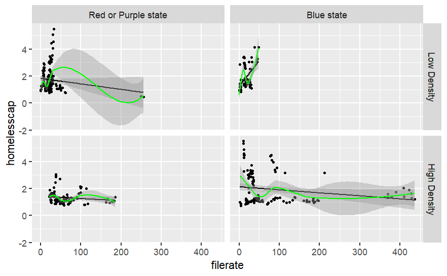

```r
dlabs = c('1' = 'High Density', '0' = 'Low Density')
blabs = c('1' = 'Blue state', '0' = 'Red or Purple state')

base + geom_point(size = 0.8) +
  geom_smooth(method = 'lm', color = 'black', linewidth = .7) +
  geom_smooth(color = 'green', linewidth = .7) +
  facet_grid(rows = vars(dense), cols = vars(blue),
             labeller = labeller(blue = blabs, dense = dlabs))
```

need to truncate output. i can keep a table of all the coefficients somewhere else

$~$

#### Fixed-effects model (within)

[figure not shown]

```r
par(mfrow=c(1, 2))

plot(lsdv_model, which = 1:2)
```

- introduce state fixed effects ** initial fe reg: explain overall, between and within variation ** do a hausman test seems easy enough ** focus on within variation?? or time demean? ** maybe also a first differences test?
- non linearity (how to combine nonlinearity with fixed effects?) ** EXPORT SOME TABLES?
- find some tests to do to figure out best model ig

## Discussion & conclusion

We could look more into our sample and data sources. we already know that the PIT counts are flawed measures, plus we could further investigate our panel dataset to see why it is unbalanced and doesnt have all states represented.

outliers handled w fe? or remove?

** dont include all diagnostic graphs in this notebook. put them in a different script for those interested